# Rookery Bay Aquatic Preserve

### Chlorophyll a, Uncorrected for Pheophytin - Discrete

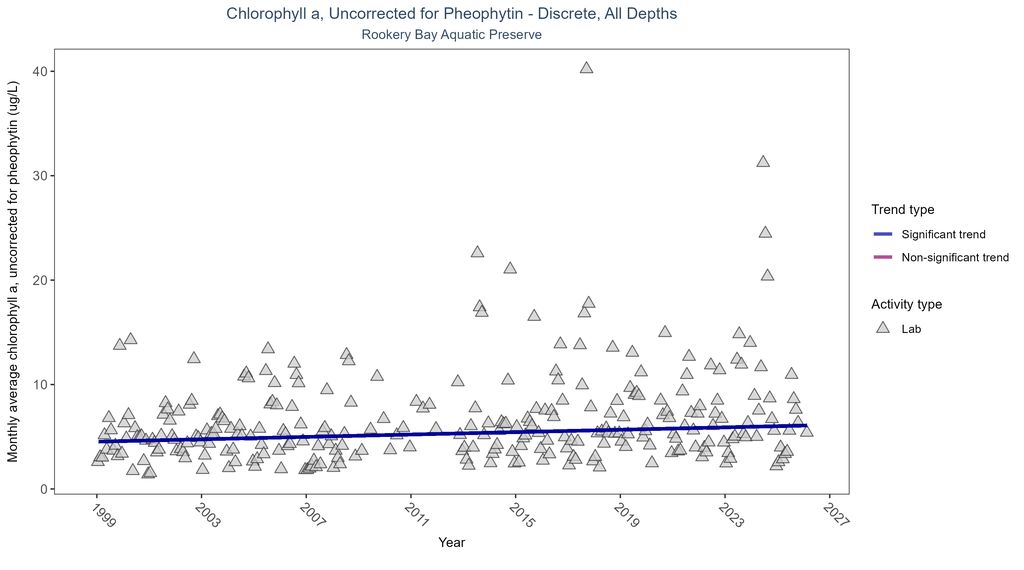

Scatter plot of monthly average levels of chlorophyll a, uncorrected for pheophytin, over time. If the time series included ten or more years of discrete observations, a significant (blue) or non-significant (magenta) trend line is also shown. Only laboratory-analyzed chlorophyll a (triangles) is included in the plot.

Table:

Monthly average chlorophyll a, uncorrected for pheophytin, increased by 0.06 µg/L per year, indicating a decrease in water clarity.

| Activity Type | Statistical Trend | Sample Count | Years with Data | Period of Record | Median Result Value | Tau | Sen Intercept | Sen Slope | P |
| --- | --- | --- | --- | --- | --- | --- | --- | --- | --- |
| Lab | Increasing trend | 3329 | 28 | 1999 - 2026 | 5 | 0.17399 | 4.52693 | 0.05711 | 0.0001 |

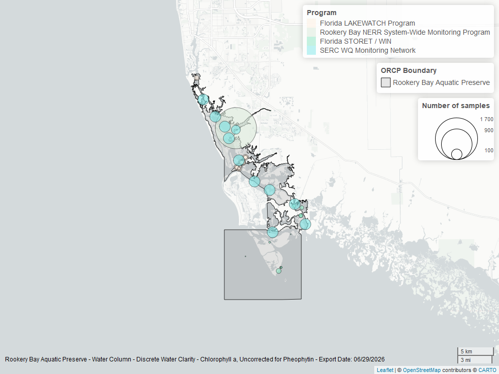

Map showing location of discrete water quality sampling locations within the boundaries of *Rookery Bay Aquatic Preserve*. The bubble size on the maps above reflect the amount of data available at each sampling site.

### Chlorophyll a, Corrected for Pheophytin - Discrete

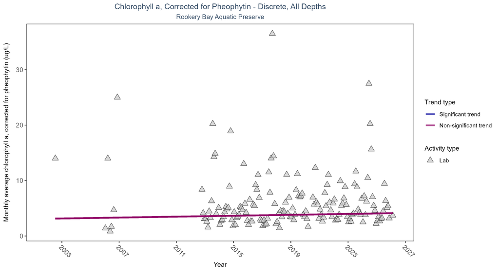

Scatter plot of monthly average levels of chlorophyll a, corrected for pheophytin, over time. If the time series included ten or more years of discrete observations, a significant (blue) or non-significant (magenta) trend line is also shown. Only laboratory-analyzed chlorophyll a (triangles) is included in the plot.

Table:

Chlorophyll a, corrected for pheophytin, showed no detectable trend between 2002 and 2026.

| Activity Type | Statistical Trend | Sample Count | Years with Data | Period of Record | Median Result Value | Tau | Sen Intercept | Sen Slope | P |
| --- | --- | --- | --- | --- | --- | --- | --- | --- | --- |
| Lab | No detectable trend | 1762 | 17 | 2002 - 2026 | 4.3 | 0.07653 | 3.11785 | 0.0413 | 0.1949 |

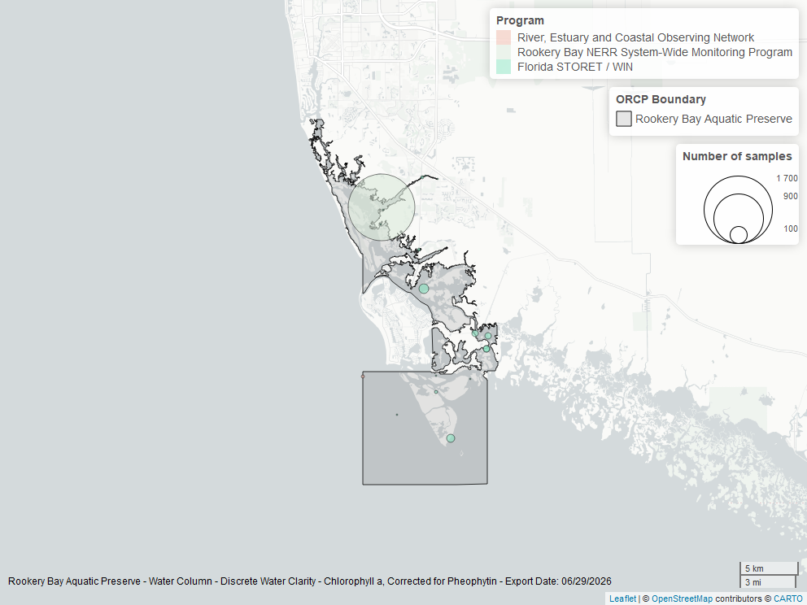

Map showing location of discrete water quality sampling locations within the boundaries of *Rookery Bay Aquatic Preserve*. The bubble size on the maps above reflect the amount of data available at each sampling site.

### Secchi Depth - Discrete

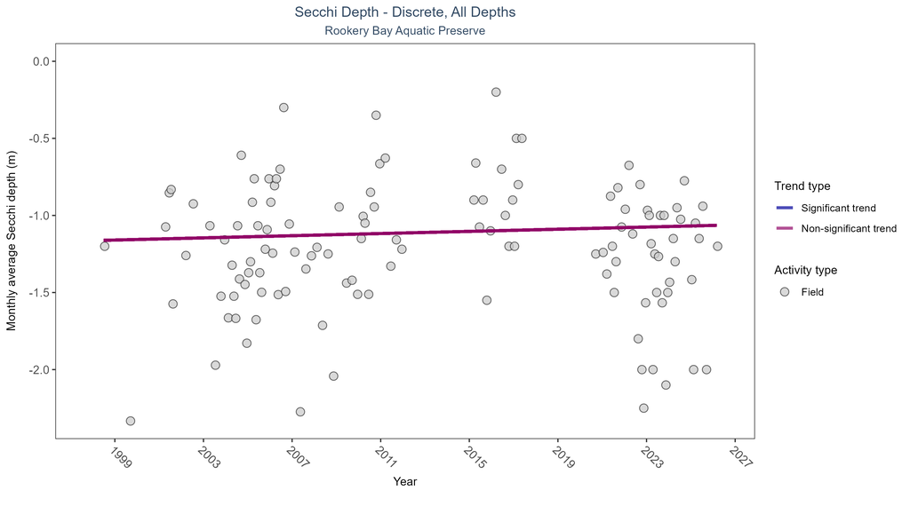

Scatter plot of monthly average Secchi depth over time. If the time series included ten or more years of discrete observations, a significant (blue) or non-significant (magenta) trend line is also shown. Secchi depth is only measured in the field (circles).

Table:

Secchi depth showed no detectable trend between 1998 and 2026.

| Activity Type | Statistical Trend | Sample Count | Years with Data | Period of Record | Median Result Value | Tau | Sen Intercept | Sen Slope | P |
| --- | --- | --- | --- | --- | --- | --- | --- | --- | --- |
| Field | No detectable trend | 442 | 23 | 1998 - 2026 | -1.2 | 0.03973 | -1.16309 | 0.00351 | 0.5308 |

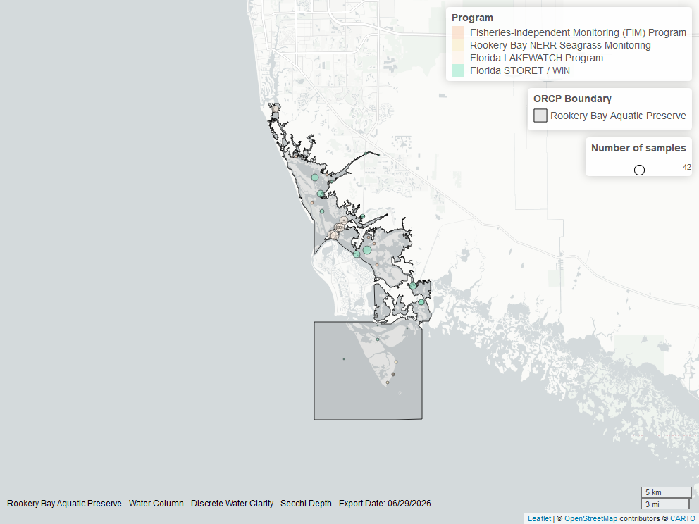

Map showing location of discrete water quality sampling locations within the boundaries of *Rookery Bay Aquatic Preserve*. The bubble size on the maps above reflect the amount of data available at each sampling site.

### Colored Dissolved Organic Matter - Discrete

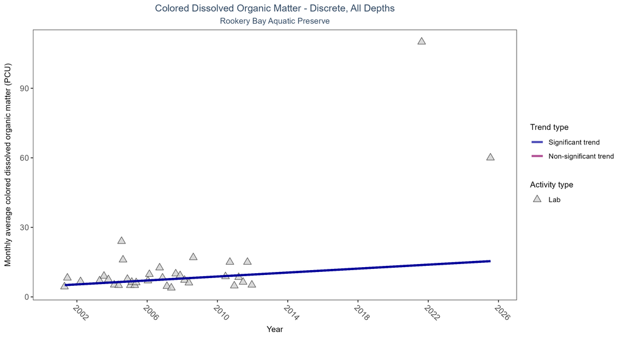

Scatter plot of monthly average colored dissolved organic matter (CDOM) over time. If the time series included ten or more years of discrete observations, a significant (blue) or non-significant (magenta) trend line is also shown. Only laboratory-analyzed CDOM (triangles) is included in the plot.

Table:

Monthly average colored dissolved organic matter increased by 0.43 PCU per year, indicating a decrease in water clarity.

| Activity Type | Statistical Trend | Sample Count | Years with Data | Period of Record | Median Result Value | Tau | Sen Intercept | Sen Slope | P |
| --- | --- | --- | --- | --- | --- | --- | --- | --- | --- |
| Lab | Increasing trend | 184 | 12 | 2001 - 2025 | 7 | 0.51961 | 4.96181 | 0.42619 | 0.03 |

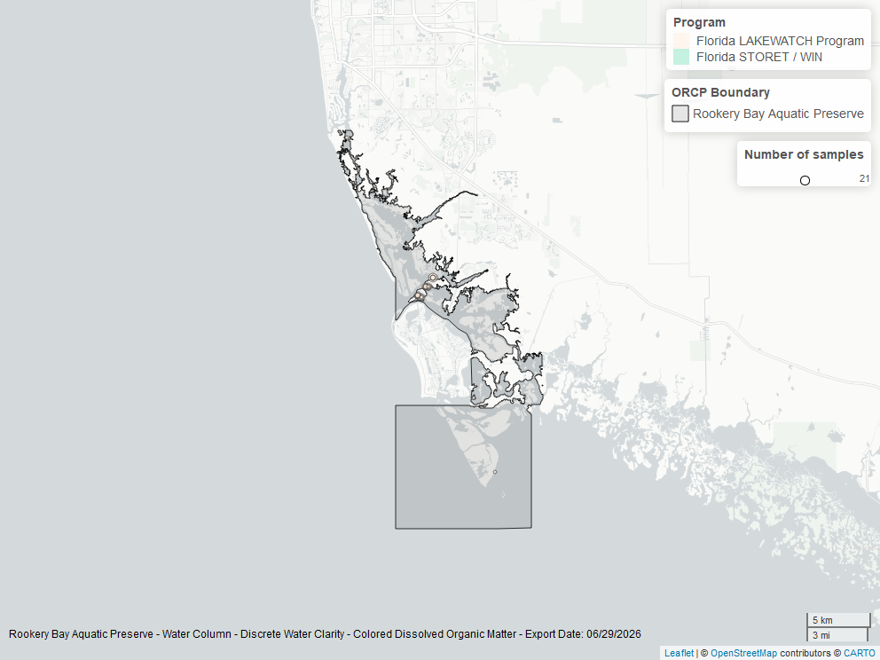

Map showing location of discrete water quality sampling locations within the boundaries of *Rookery Bay Aquatic Preserve*. The bubble size on the maps above reflect the amount of data available at each sampling site.